# Projet de Statistical Learning

### 3.3.3 **Interprétation du graphique Erreur OOB en fonction de nodesize**

```r
nodesize_values <- c(1,2, 3,4, 5,6,7,8,9, 10,12,14, 15, 18,20, 30)

oob_nodesize_results <- data.frame(
  nodesize = nodesize_values,
  oob_error = numeric(length(nodesize_values))
)

set.seed(123)
for (i in seq_along(nodesize_values)) {

  cat("Evaluation avec nodesize =", nodesize_values[i], "\n")

  # Construction du modèle avec différentes valeurs de nodesize
  rf_model <- randomForest(
    TravelInsurance ~ Age + AnnualIncome + Employment_Type +
                      GraduateOrNot + ChronicDiseases + FrequentFlyer + EverTravelledAbroad,
    data = training_set,
    ntree = 100,                 # Nombre fixe d'arbres
    nodesize = nodesize_values[i], # Valeur variable de nodesize
    mtry = best_mtry_oob,        # Utilisation du meilleur mtry trouvé précédemment
    importance = FALSE,
    do.trace = FALSE
  )

  # Stockage de l'erreur OOB
  oob_nodesize_results$oob_error[i] <- tail(rf_model$err.rate[, "OOB"], 1)
}
```

```
## Evaluation avec nodesize = 1
## Evaluation avec nodesize = 2
## Evaluation avec nodesize = 3
## Evaluation avec nodesize = 4
## Evaluation avec nodesize = 5
## Evaluation avec nodesize = 6
## Evaluation avec nodesize = 7
## Evaluation avec nodesize = 8
## Evaluation avec nodesize = 9
## Evaluation avec nodesize = 10
## Evaluation avec nodesize = 12
## Evaluation avec nodesize = 14
## Evaluation avec nodesize = 15
## Evaluation avec nodesize = 18
## Evaluation avec nodesize = 20
## Evaluation avec nodesize = 30
```

```r
# Affichage des résultats
print(oob_nodesize_results)
```

```
##    nodesize oob_error
## 1         1 0.2132075
## 2         2 0.2157233
## 3         3 0.2106918
## 4         4 0.2125786
## 5         5 0.2132075
## 6         6 0.2157233
## 7         7 0.2125786
## 8         8 0.2163522
## 9         9 0.2138365
## 10       10 0.2176101
## 11       12 0.2163522
## 12       14 0.2163522
## 13       15 0.2144654
## 14       18 0.2157233
## 15       20 0.2138365
## 16       30 0.2182390
```

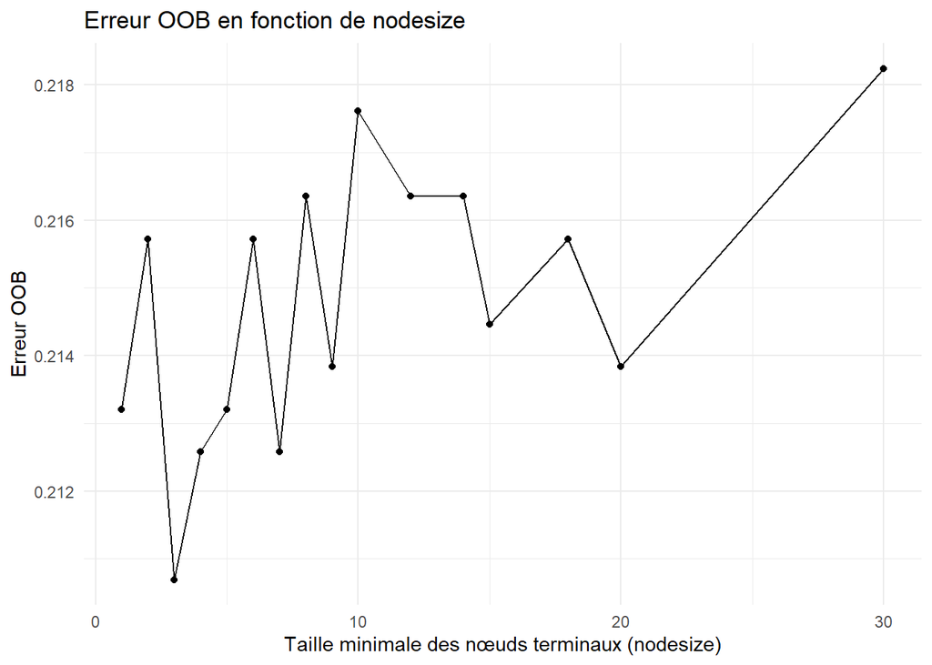

```r
# Graphique de l'erreur OOB en fonction de nodesize
ggplot(oob_nodesize_results, aes(x = nodesize, y = oob_error)) +
  geom_line() +
  geom_point() +
  theme_minimal() +
  labs(title = "Erreur OOB en fonction de nodesize",
       x = "Taille minimale des nœuds terminaux (nodesize)",
       y = "Erreur OOB")
```

```r
# Identification du meilleur nodesize selon l'erreur OOB
best_nodesize_oob <- nodesize_values[which.min(oob_nodesize_results$oob_error)]
```

**Analyse de l’erreur OOB en fonction du paramètre `nodesize`**

Ainsi, une petite valeur de `nodesize`, typiquement autour de **2 à 5**, semble optimale pour ce modèle.

### 3.3.4 **Estimation de la performance par validation croisée en fonction de ntrees**

```r
ntrees_values <- seq(10, 500, by = 20)


# Validation croisée pour l’accuracy

ctrl <- trainControl(
  method = "cv",
  number = 5,
  summaryFunction = defaultSummary
)

cv_ntrees_results <- data.frame(
  ntrees = ntrees_values,
  Accuracy = numeric(length(ntrees_values))
)

for (i in seq_along(ntrees_values)) {

  param_grid <- expand.grid(mtry = best_mtry_oob)

  set.seed(123 + i)
  cv_model <- train(
    TravelInsurance ~ Age + AnnualIncome + Employment_Type +
                      GraduateOrNot + ChronicDiseases + FrequentFlyer + EverTravelledAbroad,
    data = training_set,
    method = "rf",
    metric = "Accuracy",
    trControl = ctrl,
    tuneGrid = param_grid,
    ntree = ntrees_values[i]
  )

  cv_ntrees_results$Accuracy[i] <- cv_model$results$Accuracy
}

# Affichage
print(cv_ntrees_results)
```

```
##    ntrees  Accuracy
## 1      10 0.7786373
## 2      30 0.7836509
## 3      50 0.7861263
## 4      70 0.7874462
## 5      90 0.7874403
## 6     110 0.7867967
## 7     130 0.7893450
## 8     150 0.7899680
## 9     170 0.7880613
## 10    190 0.7868015
## 11    210 0.7868015
## 12    230 0.7836390
## 13    250 0.7861646
## 14    270 0.7867749
## 15    290 0.7805311
## 16    310 0.7824080
## 17    330 0.7798742
## 18    350 0.7817731
## 19    370 0.7868292
## 20    390 0.7836856
## 21    410 0.7868054
## 22    430 0.7836480
## 23    450 0.7817483
## 24    470 0.7893164
## 25    490 0.7817610
```

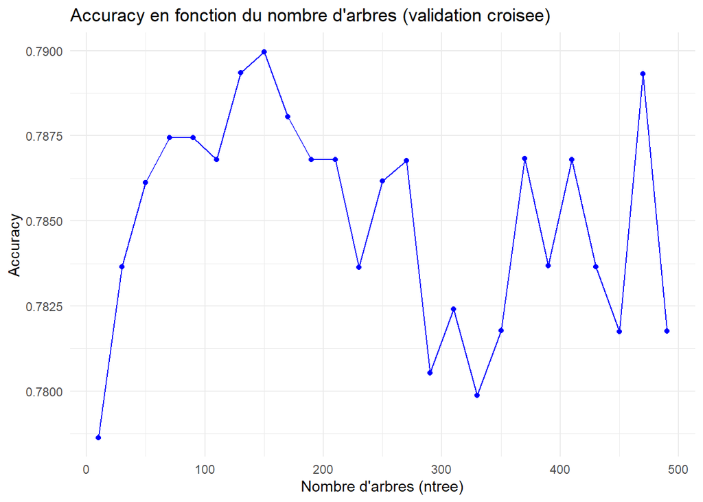

```r
# Courbe de l’Accuracy
ggplot(cv_ntrees_results, aes(x = ntrees, y = Accuracy)) +
  geom_line(color = "blue") +
  geom_point(color = "blue") +
  theme_minimal() +
  labs(title = "Accuracy en fonction du nombre d'arbres (validation croisee)",
       x = "Nombre d'arbres (ntree)",
       y = "Accuracy")
```

```r
# Meilleur ntree

best_ntrees_cv <- ntrees_values[which.max(cv_ntrees_results$Accuracy)]
```

**Évolution de l’accuracy en fonction du nombre d’arbres (ntree)**

Le graphique ci-dessus illustre la performance du modèle Random Forest mesurée par l’**accuracy** lors d’une **validation croisée à 5 plis**, en fonction du nombre d’arbres construits (paramètre `ntree`).

Cela indique que **150 arbres suffisent à atteindre une performance optimale**, et qu’augmenter davantage la complexité (ntree > 150) **n’améliore pas la précision**, tout en **augmentant le temps de calcul**.

**Conclusion** : Le nombre optimal d’arbres pour ce modèle est proche de **150**, ce qui permet de concilier performance et efficacité computationnelle.

```r
library(ranger)

# Définir les grilles d'hyperparamètres

mtry_grid <- c(2, 3, 4, 5, 6, 7)
nodesize_grid <- c(1, 2, 3, 4, 5, 6, 7, 8, 9, 10, 12, 14, 15, 18, 20, 30)

# Configuration de la validation croisée

ctrl <- trainControl(
  method = "cv",
  number = 5,
  classProbs = TRUE,
  summaryFunction = twoClassSummary,
  verboseIter = TRUE
)

# Créer la grille complète avec splitrule (nécessaire pour ranger)

full_grid <- expand.grid(
  mtry = mtry_grid,
  splitrule = "gini",  # Requis pour ranger (options: gini, extratrees, hellinger)
  min.node.size = nodesize_grid
)

# Exécution de la validation croisée

set.seed(123)

cv_full <- train(
  TravelInsurance ~ Age + AnnualIncome + Employment_Type +
    GraduateOrNot + ChronicDiseases + FrequentFlyer + EverTravelledAbroad,
  data = training_set,
  method = "ranger",  # Utilisation de ranger pour ajuster min.node.size
  num.trees = best_ntrees_cv,
  metric = "ROC",
  trControl = ctrl,
  tuneGrid = full_grid,
  importance = "impurity"
)
cat("\n Meilleurs hyperparametres selon la validation croisee complete:\n")
```

```
##
##  Meilleurs hyperparametres selon la validation croisee complete:
```

```r
print(cv_full$bestTune)
```

```
##    mtry splitrule min.node.size
## 16    2      gini            30
```

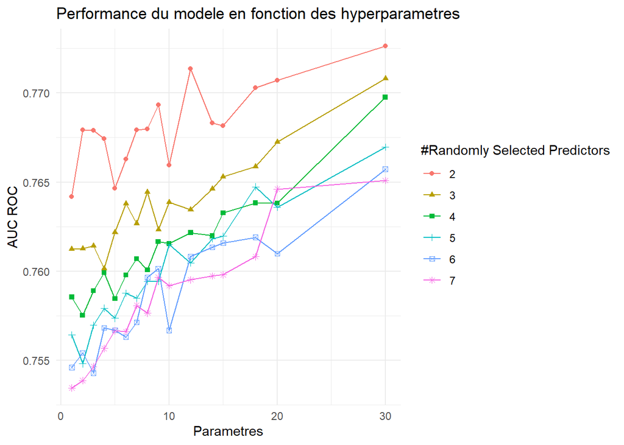

```r
# Visualisation des résultats

ggplot(cv_full) +
  theme_minimal() +
  labs(title = "Performance du modele en fonction des hyperparametres",
       x = "Parametres",
       y = "AUC ROC")
```

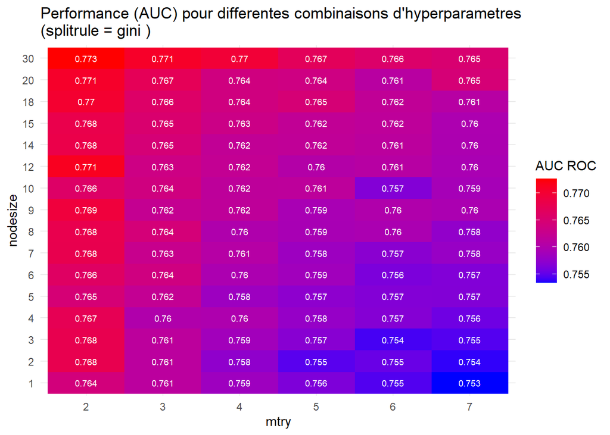

```r
# Graphique spécifique pour mieux visualiser les interactions
cv_results <- cv_full$results

# Trouver la meilleure règle de division (splitrule)
best_splitrule <- cv_full$bestTune$splitrule

# Filtrer les résultats pour la meilleure règle de division

filtered_results <- cv_results[cv_results$splitrule == best_splitrule, ]

# Créer la heatmap
ggplot(filtered_results, aes(x = as.factor(mtry), y = as.factor(min.node.size), fill = ROC)) +
  geom_tile() +
  geom_text(aes(label = round(ROC, 3)), color = "white", size = 2.5) +
  scale_fill_gradient(low = "blue", high = "red") +
  theme_minimal() +
  labs(title = paste("Performance (AUC) pour differentes combinaisons d'hyperparametres\n(splitrule =", best_splitrule, ")"),
       x = "mtry",
       y = "nodesize",
       fill = "AUC ROC")
```

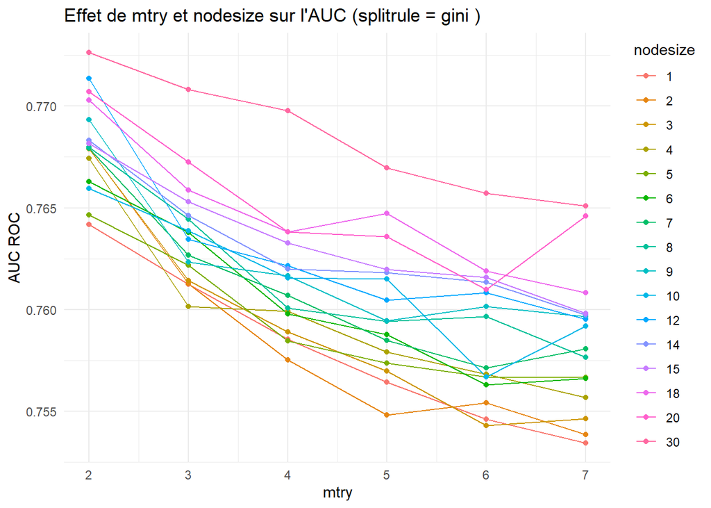

```r
# Création d'un graphique de ligne pour visualiser l'effet de mtry pour différents nodesize
ggplot(filtered_results, aes(x = mtry, y = ROC, color = as.factor(min.node.size), group = as.factor(min.node.size))) +
  geom_line() +
  geom_point() +
  theme_minimal() +
  labs(title = paste("Effet de mtry et nodesize sur l'AUC (splitrule =", best_splitrule, ")"),
       x = "mtry",
       y = "AUC ROC",
       color = "nodesize")
```

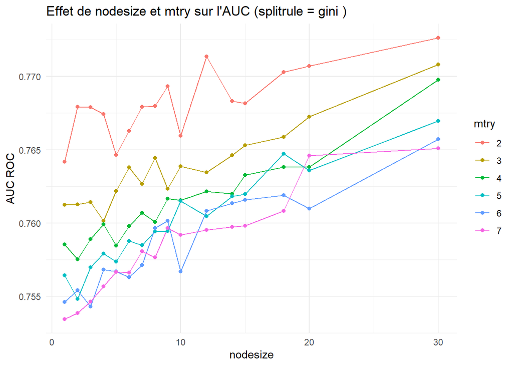

```r
# Création d'un graphique de ligne pour visualiser l'effet de nodesize pour différents mtry
ggplot(filtered_results, aes(x = min.node.size, y = ROC, color = as.factor(mtry), group = as.factor(mtry))) +
  geom_line() +
  geom_point() +
  theme_minimal() +
  labs(title = paste("Effet de nodesize et mtry sur l'AUC (splitrule =", best_splitrule, ")"),
       x = "nodesize",
       y = "AUC ROC",
       color = "mtry")
```

**Graphique 2 : Effet croisé de `mtry` et `nodesize` sur l’AUC**

Ce graphique explore l’impact combiné de `mtry` (axe x) et `nodesize` sur l’AUC.

- **Observation clé** : Plus `mtry` augmente, plus l’AUC a tendance à décroître, surtout pour les `nodesize` faibles.
- **Interprétation** : Une valeur élevée de `mtry` diminue la variance entre les arbres, ce qui réduit la capacité de généralisation du modèle. Cela confirme que **trop d’information à chaque split nuit à la performance**.

**Graphique 3 : Effet croisé de `nodesize` et `mtry` sur l’AUC**

Cette fois, l’axe des x est `nodesize` (taille minimale des feuilles), avec une couleur par valeur de `mtry`.

- **Observation clé** : À `mtry = 2`, la performance augmente avec `nodesize`, atteignant un maximum vers 30.
- **Interprétation** : Cela suggère que pour un `mtry` faible (donc des splits très variés), augmenter `nodesize` permet de lisser les arbres, évitant l’overfitting. En revanche, pour des `mtry` plus élevés, l’impact est moins clair.

Ces trois graphiques démontrent l’importance de l’interaction entre les hyperparamètres `mtry` et `nodesize`. La meilleure performance est obtenue avec `mtry = 2` et un `nodesize` autour de 20–30, ce qui confirme que **plus de diversité entre les arbres combiné à une régularisation des feuilles terminales** favorise la généralisation du modèle Random Forest.

### 3.3.5 **Reconstruction du modele final avec les meilleurs hyperparametres de la cross validation**

```r
final_mtry <- cv_full$bestTune$mtry
final_nodesize <- cv_full$bestTune$min.node.size
final_ntrees <- best_ntrees_cv

set.seed(123)
final_rf <- randomForest(
  TravelInsurance ~ Age + AnnualIncome + Employment_Type +
                    GraduateOrNot + ChronicDiseases + FrequentFlyer + EverTravelledAbroad,
  data = training_set,
  ntree = final_ntrees,
  nodesize = final_nodesize,
  mtry = final_mtry,
  importance = TRUE,
  keep.forest = TRUE,
  do.trace = TRUE
)
```

```
## ntree      OOB      1      2
##     1:  21.56%  6.08% 49.29%
##     2:  21.05%  4.97% 51.36%
##     3:  21.92%  4.12% 54.89%
##     4:  23.02%  5.52% 54.55%
##     5:  22.18%  4.65% 54.49%
##     6:  22.48%  5.21% 53.99%
##     7:  22.13%  4.78% 53.49%
##     8:  22.13%  4.60% 53.90%
##     9:  21.60%  3.77% 53.96%
##    10:  22.41%  4.73% 54.68%
##    11:  21.81%  4.03% 54.11%
##    12:  21.87%  4.22% 53.82%
##    13:  22.10%  4.51% 53.90%
##    14:  22.15%  4.41% 54.16%
```

[output cut: 136 more lines]

```r
print(final_rf)
```

```
##
## Call:
##  randomForest(formula = TravelInsurance ~ Age + AnnualIncome +      Employment_Type + GraduateOrNot + ChronicDiseases + FrequentFlyer +      EverTravelledAbroad, data = training_set, ntree = final_ntrees,      nodesize = final_nodesize, mtry = final_mtry, importance = TRUE,      keep.forest = TRU…
##                Type of random forest: classification
##                      Number of trees: 150
## No. of variables tried at each split: 2
##
##         OOB estimate of  error rate: 21.51%
## Confusion matrix:
##       No Yes class.error
## No  1003  19    0.018591
## Yes  323 245    0.568662
```

```r
cat("\nErreur OOB finale:", tail(final_rf$err.rate[, "OOB"], 1), "\n")
```

```
##
## Erreur OOB finale: 0.2150943
```

### 3.3.6 **Importance des variables** :

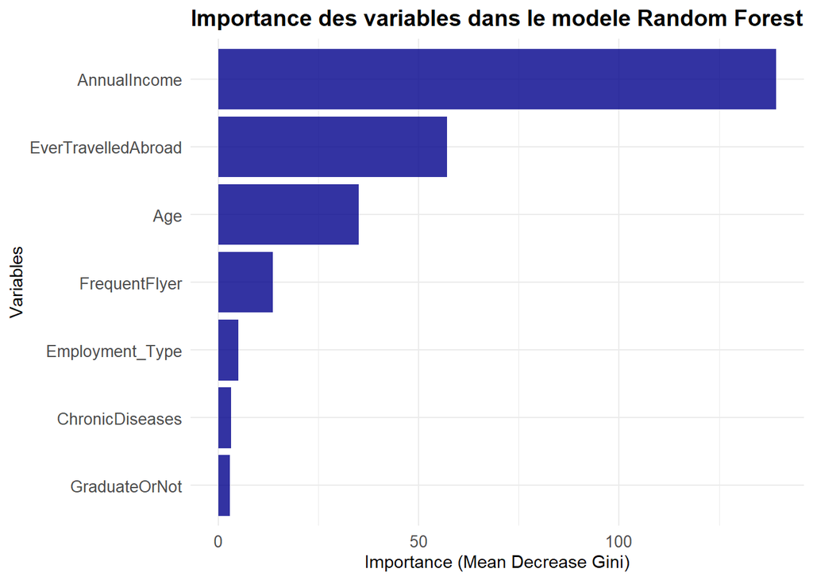

```r
var_importance <- final_rf$importance
importance_df <- data.frame(
  Variable = rownames(var_importance),
  Importance = var_importance[, "MeanDecreaseGini"]
)

importance_df <- importance_df %>%
  arrange(Importance)

ggplot(importance_df, aes(x = reorder(Variable, Importance), y = Importance)) +
  geom_col(fill = "darkblue", alpha = 0.8) +
  coord_flip() +
  labs(
    title = "Importance des variables dans le modele Random Forest",
    x = "Variables",
    y = "Importance (Mean Decrease Gini)"
  ) +
  theme_minimal() +
  theme(
    plot.title = element_text(hjust = 0.5, size = 14, face = "bold"),
    axis.text.y = element_text(size = 10),
    axis.text.x = element_text(size = 10)
  )
```

### 3.3.7 **Diagrammes de dependance partielle des variables**

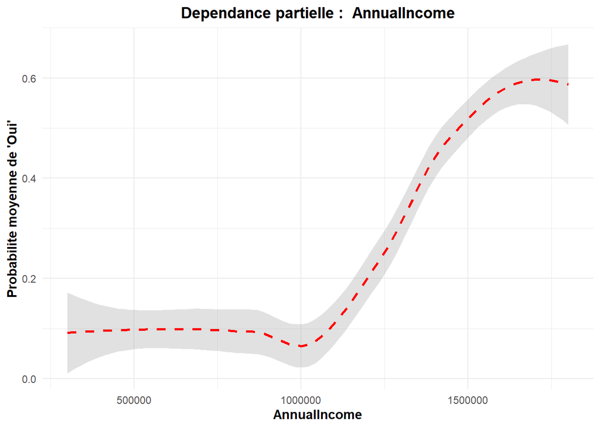

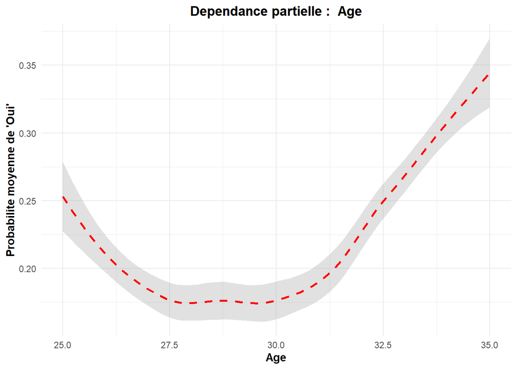

```r
create_pdp_continuous_ggplot <- function(model, data, variable) {

  min_val <- min(data[[variable]], na.rm = TRUE)
  max_val <- max(data[[variable]], na.rm = TRUE)

  grid_size <- 50
  grid_values <- seq(min_val, max_val, length.out = grid_size)

  predictions <- numeric(grid_size)

  for (i in seq_along(grid_values)) {

    temp_data <- data

    temp_data[[variable]] <- grid_values[i]

    preds <- predict(model, temp_data, type = "prob")

    predictions[i] <- mean(preds[, "Yes"], na.rm = TRUE)
  }

  pdp_df <- data.frame(
    x = grid_values,
    y = predictions
  )
  names(pdp_df) <- c(variable, "probability")

  # Créer le graphique avec ggplot2

  p <- ggplot(pdp_df, aes_string(x = variable, y = "probability")) +
    geom_smooth(method = "loess", se = TRUE, color = "red", linetype = "dashed", alpha = 0.3) +
    theme_minimal() +
    labs(title = paste("Dependance partielle : ", variable),
         x = variable,
         y = "Probabilite moyenne de 'Oui'") +
    theme(plot.title = element_text(hjust = 0.5, face = "bold"),
          axis.title = element_text(face = "bold"))

  return(list(plot = p, data = pdp_df))
}


# Identifier les variables continues et catégorielles
continuous_vars <- intersect(top_vars, c("Age", "AnnualIncome"))

pdp_plots <- list()

# Créer les graphiques pour les variables continues

for (var in continuous_vars) {
  tryCatch({
    result <- create_pdp_continuous_ggplot(final_rf, training_set, var)
    pdp_plots[[var]] <- result$plot
  })
}


# Afficher les graphiques individuellement
for (var in names(pdp_plots)) {
  print(pdp_plots[[var]])
}
```

**1. AnnualIncome – Probabilité d’assurance voyage**

**Graphique** : `Partial Dependence Plot` pour la variable continue `AnnualIncome`.

**Interprétation** : On observe une nette relation positive entre le revenu annuel et la probabilité de souscription à une assurance voyage.

**Conclusion** : Le revenu annuel est un facteur déterminant. Plus l’individu a un revenu élevé, plus il est susceptible de souscrire à l’assurance voyage.

**2. Age – Probabilité d’assurance voyage**

**Graphique** : `Partial Dependence Plot` pour la variable `Age`.

**Conclusion** : Le modèle détecte une influence positive de l’âge sur la propension à souscrire, surtout à partir de la trentaine.

## 3.4 **Méthodes d’Ensemble : Gradient Boosting**

Cette méthode repose sur l’utilisation d’une **fonction de lien**, en l’occurrence la **fonction logit**, définie par :

$$f(x) = \frac{x}{1 - x}, \quad \text{avec } x \in [0, 1]$$
Cette fonction est adaptée ici car la problématique relève d’un cas de **classification binaire**, analogue à l’estimation du **nombre d’occurrences de sinistres** en actuariat.

Dans le modèle, la **distribution binomiale** est spécifiée pour refléter la nature binaire de la variable cible, et pour assurer la cohérence avec la fonction de lien logit. Ce choix permet d’exploiter la correspondance naturelle entre la distribution binomiale et le lien logit dans le cadre des modèles linéaires généralisés (GLM).

Le code suivant en donne une implémentation sous **R** :

```r
training_set$TravelInsurance_num <- ifelse(training_set$TravelInsurance == "Yes", 1, 0)
testing_set$TravelInsurance_num <- ifelse(testing_set$TravelInsurance == "Yes", 1, 0)

categorical_vars <- c("Employment_Type", "GraduateOrNot", "ChronicDiseases", "FrequentFlyer", "EverTravelledAbroad")
for (var in categorical_vars) {
  training_set[[var]] <- as.factor(training_set[[var]])
  testing_set[[var]] <- as.factor(testing_set[[var]])
}

gbm_initial <- gbm(TravelInsurance_num ~ Age + AnnualIncome + Employment_Type +
                     GraduateOrNot + ChronicDiseases + FrequentFlyer + EverTravelledAbroad,
                   data = training_set,
                   distribution = "bernoulli",  # Distribution bernoulli avec lien logit
                   n.trees = 100,              # Nombre initial d'arbres
                   interaction.depth = 3,      # Profondeur d'interaction initiale
                   shrinkage = 0.1,            # Shrinkage initial
                   bag.fraction = 0.5,         # Fraction d'observations utilisées
                   cv.folds = 5,               # Validation croisée à 5 plis
                   train.fraction = 0.8,
                   verbose = FALSE)
```

### 3.4.1 **Estimation de la performance du modèle par validation croisée en fonction des hyperparamètres clés**

```r
# Définition des grilles d'hyperparamètres à tester

n_trees_grid <- c(10,20,30,50,60,70,80,90,100,150,180, 200, 230,270,300, 500)

interaction_depth_grid <- c(2, 3, 5, 7)

bag_fraction_grid <- c(0.5, 0.7, 0.9)

shrinkage_grid <- c(0.01,0.02,0.03,0.04, 0.05, 0.1, 0.2,0.3,0.5)

# Initialisation d'un dataframe pour stocker les résultats
results <- data.frame()

for (n_trees in n_trees_grid) {
  for (interaction_depth in interaction_depth_grid) {
    cat("  Test avec n_trees =", n_trees, "et interaction_depth =", interaction_depth, "\n")

    set.seed(123)
    cv_model <- gbm(TravelInsurance_num ~ Age + AnnualIncome + Employment_Type +
                      GraduateOrNot + ChronicDiseases + FrequentFlyer + EverTravelledAbroad,
                    data = training_set,
                    distribution = "bernoulli",
                    n.trees = n_trees,
                    interaction.depth = interaction_depth,
                    shrinkage = 0.1,  # Valeur fixe pour cette étape
                    bag.fraction = 0.5,  # Valeur fixe pour cette étape
                    cv.folds = 5,
                    train.fraction = 0.8,
                    verbose = FALSE)

    # Trouver le nombre optimal d'arbres
    best_iter <- gbm.perf(cv_model, method = "cv", plot.it = FALSE)
    cv_error <- cv_model$cv.error[best_iter]

    # Stocker les résultats
    results <- rbind(results, data.frame(
      n_trees = n_trees,
      interaction_depth = interaction_depth,
      bag_fraction = 0.5,
      shrinkage = 0.1,
      best_iter = best_iter,
      cv_error = cv_error
    ))
  }
}
```

```
##   Test avec n_trees = 10 et interaction_depth = 2
##   Test avec n_trees = 10 et interaction_depth = 3
##   Test avec n_trees = 10 et interaction_depth = 5
##   Test avec n_trees = 10 et interaction_depth = 7
##   Test avec n_trees = 20 et interaction_depth = 2
##   Test avec n_trees = 20 et interaction_depth = 3
##   Test avec n_trees = 20 et interaction_depth = 5
##   Test avec n_trees = 20 et interaction_depth = 7
##   Test avec n_trees = 30 et interaction_depth = 2
##   Test avec n_trees = 30 et interaction_depth = 3
##   Test avec n_trees = 30 et interaction_depth = 5
##   Test avec n_trees = 30 et interaction_depth = 7
##   Test avec n_trees = 50 et interaction_depth = 2
##   Test avec n_trees = 50 et interaction_depth = 3
##   Test avec n_trees = 50 et interaction_depth = 5
##   Test avec n_trees = 50 et interaction_depth = 7
##   Test avec n_trees = 60 et interaction_depth = 2
##   Test avec n_trees = 60 et interaction_depth = 3
##   Test avec n_trees = 60 et interaction_depth = 5
##   Test avec n_trees = 60 et interaction_depth = 7
##   Test avec n_trees = 70 et interaction_depth = 2
##   Test avec n_trees = 70 et interaction_depth = 3
##   Test avec n_trees = 70 et interaction_depth = 5
##   Test avec n_trees = 70 et interaction_depth = 7
##   Test avec n_trees = 80 et interaction_depth = 2
##   Test avec n_trees = 80 et interaction_depth = 3
##   Test avec n_trees = 80 et interaction_depth = 5
##   Test avec n_trees = 80 et interaction_depth = 7
##   Test avec n_trees = 90 et interaction_depth = 2
##   Test avec n_trees = 90 et interaction_depth = 3
##   Test avec n_trees = 90 et interaction_depth = 5
##   Test avec n_trees = 90 et interaction_depth = 7
##   Test avec n_trees = 100 et interaction_depth = 2
##   Test avec n_trees = 100 et interaction_depth = 3
##   Test avec n_trees = 100 et interaction_depth = 5
##   Test avec n_trees = 100 et interaction_depth = 7
##   Test avec n_trees = 150 et interaction_depth = 2
##   Test avec n_trees = 150 et interaction_depth = 3
##   Test avec n_trees = 150 et interaction_depth = 5
##   Test avec n_trees = 150 et interaction_depth = 7
```

[output cut: 9 more lines]

```
##   Test avec n_trees = 230 et interaction_depth = 3
##   Test avec n_trees = 230 et interaction_depth = 5
##   Test avec n_trees = 230 et interaction_depth = 7
##   Test avec n_trees = 270 et interaction_depth = 2
##   Test avec n_trees = 270 et interaction_depth = 3
##   Test avec n_trees = 270 et interaction_depth = 5
##   Test avec n_trees = 270 et interaction_depth = 7
##   Test avec n_trees = 300 et interaction_depth = 2
##   Test avec n_trees = 300 et interaction_depth = 3
##   Test avec n_trees = 300 et interaction_depth = 5
##   Test avec n_trees = 300 et interaction_depth = 7
##   Test avec n_trees = 500 et interaction_depth = 2
##   Test avec n_trees = 500 et interaction_depth = 3
##   Test avec n_trees = 500 et interaction_depth = 5
##   Test avec n_trees = 500 et interaction_depth = 7
```

```r
# Trouver les meilleurs paramètres de cette première étape

best_params_1 <- results[which.min(results$cv_error), ]

cat("\nMeilleurs paramètres (étape 1):\n")
```

```
##
## Meilleurs paramètres (étape 1):
```

```r
print(best_params_1)
```

```
##    n_trees interaction_depth bag_fraction shrinkage best_iter  cv_error
## 14      50                 3          0.5       0.1        39 0.9758828
```

```r
# 2. Ensuite, avec les meilleurs n_trees et interaction_depth, optimiser bag_fraction et shrinkage
cat("\n2. Optimisation de bag_fraction et shrinkage...\n")
```

```
##
## 2. Optimisation de bag_fraction et shrinkage...
```

```r
results_2 <- data.frame()

for (bag_fraction in bag_fraction_grid) {
  for (shrinkage in shrinkage_grid) {
    cat("  Test avec bag_fraction =", bag_fraction, "et shrinkage =", shrinkage, "\n")

    set.seed(42)
    cv_model <- gbm(TravelInsurance_num ~ Age + AnnualIncome + Employment_Type +
                      GraduateOrNot + ChronicDiseases + FrequentFlyer + EverTravelledAbroad,
                    data = training_set,
                    distribution = "bernoulli",
                    n.trees = best_params_1$n_trees,
                    interaction.depth = best_params_1$interaction_depth,
                    shrinkage = shrinkage,
                    bag.fraction = bag_fraction,
                    cv.folds = 5,
                    train.fraction = 0.8,
                    verbose = TRUE)

    # Trouver le nombre optimal d'arbres
    best_iter <- gbm.perf(cv_model, method = "cv", plot.it = FALSE)
    cv_error <- cv_model$cv.error[best_iter]

    # Stocker les résultats
    results_2 <- rbind(results_2, data.frame(
      n_trees = best_params_1$n_trees,
      interaction_depth = best_params_1$interaction_depth,
      bag_fraction = bag_fraction,
      shrinkage = shrinkage,
      best_iter = best_iter,
      cv_error = cv_error
    ))
  }
}
```

[output not shown]

[output cut: 389 more lines]

```r
# Trouver les meilleurs paramètres de la deuxième étape
best_params_2 <- results_2[which.min(results_2$cv_error), ]
cat("\nMeilleurs paramètres (étape 2):\n")
```

```
##
## Meilleurs paramètres (étape 2):
```

```r
print(best_params_2)
```

```
##    n_trees interaction_depth bag_fraction shrinkage best_iter  cv_error
## 25      50                 3          0.9       0.2        21 0.9622771
```

```r
# 3. Enfin, avec tous les paramètres optimisés, faire une dernière validation avec plus d'arbres
cat("\n3. Validation finale avec tous les paramètres optimisés...\n")
```

```
##
## 3. Validation finale avec tous les paramètres optimisés...
```

```r
# Ajuster le nombre maximum d'arbres en fonction du shrinkage (taux d'apprentissage)
# Avec un taux d'apprentissage plus faible, nous avons besoin de plus d'arbres

final_n_trees <- ifelse(best_params_2$shrinkage <= 0.05, 1000,
                        ifelse(best_params_2$shrinkage <= 0.1, 500, 300))

set.seed(123)
final_model <- gbm(TravelInsurance_num ~ Age + AnnualIncome + Employment_Type +
                     GraduateOrNot + ChronicDiseases + FrequentFlyer + EverTravelledAbroad,
                   data = training_set,
                   distribution = "bernoulli",
                   n.trees = final_n_trees,
                   interaction.depth = best_params_2$interaction_depth,
                   shrinkage = best_params_2$shrinkage,
                   bag.fraction = best_params_2$bag_fraction,
                   cv.folds = 5,
                   train.fraction = 0.8,
                   verbose = TRUE)
```

```
##      1        1.1910          1.1689     0.2000    0.0543
##      2        1.1188          1.0995     0.2000    0.0336
##      3        1.0701          1.0555     0.2000    0.0191
##      4        1.0359          1.0226     0.2000    0.0148
##      5        1.0131          1.0042     0.2000    0.0137
##      6        0.9947          0.9902     0.2000    0.0111
##      7        0.9815          0.9825     0.2000    0.0065
##      8        0.9713          0.9748     0.2000    0.0014
##      9        0.9643          0.9705     0.2000   -0.0012
##     10        0.9583          0.9675     0.2000   -0.0001
##     20        0.9309          0.9618     0.2000   -0.0016
##     40        0.9052          0.9654     0.2000   -0.0010
##     60        0.8910          0.9574     0.2000   -0.0015
##     80        0.8806          0.9691     0.2000   -0.0052
##    100        0.8724          0.9653     0.2000   -0.0031
##    120        0.8649          0.9679     0.2000   -0.0016
##    140        0.8595          0.9728     0.2000   -0.0047
##    160        0.8538          0.9709     0.2000   -0.0023
##    180        0.8490          0.9720     0.2000   -0.0025
##    200        0.8463          0.9760     0.2000   -0.0038
##    220        0.8429          0.9824     0.2000   -0.0018
##    240        0.8395          0.9815     0.2000   -0.0017
##    260        0.8368          0.9810     0.2000   -0.0017
##    280        0.8335          0.9767     0.2000   -0.0030
##    300        0.8319          0.9786     0.2000   -0.0021
```

```r
# Trouver le nombre optimal d'arbres

best_iter_final <- which.min(final_model$cv.error)

cat("\nMeilleur nombre d'arbres pour le modele final:", best_iter_final, "\n")
```

```
##
## Meilleur nombre d'arbres pour le modele final: 22
```

```r
cat("Erreur de validation croisee finale:", final_model$cv.error[best_iter_final], "\n")
```

```
## Erreur de validation croisee finale: 0.96887
```

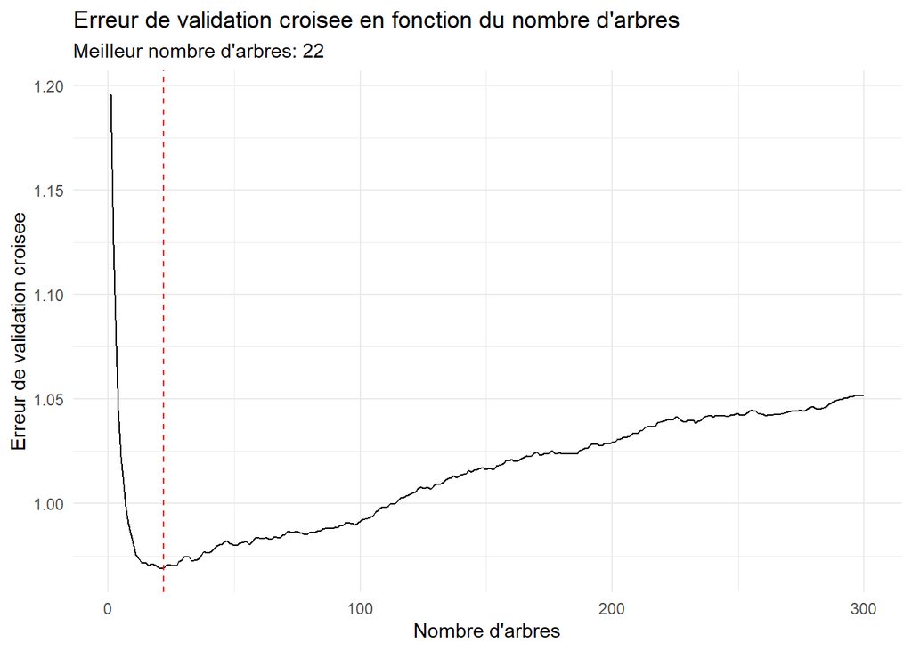

```r
# Visualisation de l'erreur de validation croisée en fonction du nombre d'arbres
ggplot(data.frame(
  n_trees = 1:length(final_model$cv.error),
  cv_error = final_model$cv.error
), aes(x = n_trees, y = cv_error)) +
  geom_line() +
  geom_vline(xintercept = best_iter_final, linetype = "dashed", color = "red") +
  theme_minimal() +
  labs(title = "Erreur de validation croisee en fonction du nombre d'arbres",
       x = "Nombre d'arbres",
       y = "Erreur de validation croisee",
       subtitle = paste("Meilleur nombre d'arbres:", best_iter_final))
```

### 3.4.2 **Importance des variables**

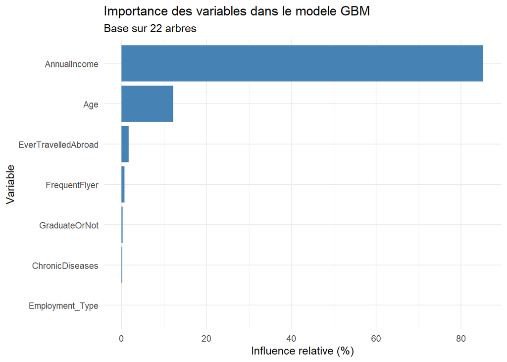

```r
# Extraire l'importance des variables
var_importance <- summary(final_model, n.trees = best_iter_final, plotit = FALSE)

# S'assurer que la structure est correcte
if (is.data.frame(var_importance)) {
  names(var_importance) <- c("variable", "relative_influence")
  var_imp_df <- var_importance
} else if (!is.null(names(var_importance))) {
  var_imp_df <- data.frame(
    variable = names(var_importance),
    relative_influence = as.numeric(var_importance)
  )
} else {
  var_imp_df <- data.frame(
    variable = paste0("var", seq_along(var_importance)),
    relative_influence = var_importance
  )
}

# Vérifier qu'on a bien des données
if (nrow(var_imp_df) == 0) {
  var_names <- final_model$var.names
  var_influence <- relative.influence(final_model, n.trees = best_iter_final)
  var_imp_df <- data.frame(
    variable = var_names,
    relative_influence = var_influence
  )
}

# Trier par influence décroissante
var_imp_df <- var_imp_df[order(-var_imp_df$relative_influence), ]

# Tracer l’importance des variables

ggplot(var_imp_df, aes(x = reorder(variable, relative_influence), y = relative_influence)) +
  geom_bar(stat = "identity", fill = "steelblue") +
  coord_flip() +
  theme_minimal() +
  labs(title = "Importance des variables dans le modele GBM",
       subtitle = paste("Base sur", best_iter_final, "arbres"),
       x = "Variable",
       y = "Influence relative (%)")
```

### 3.4.3 **Diagrammes de dependance partielle des variables**

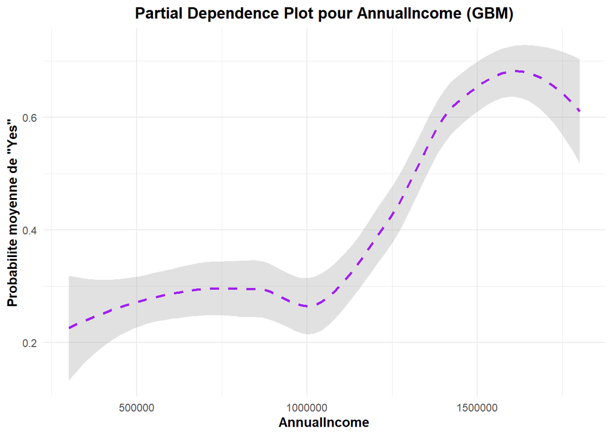

```r
create_pdp_gbm <- function(model, data, variable, best_iter, class_label = "Yes", grid_size = 50) {

  grid_vals <- seq(min(data[[variable]], na.rm = TRUE),
                   max(data[[variable]], na.rm = TRUE),
                   length.out = grid_size)

  # Vecteur pour stocker les probabilités moyennes
  prob_means <- numeric(length(grid_vals))

  for (i in seq_along(grid_vals)) {
    # Copier les données
    temp_data <- data

    # Fixer la variable à la valeur courante
    temp_data[[variable]] <- grid_vals[i]

    # Prédire les probabilités
    preds <- predict(model, newdata = temp_data, n.trees = best_iter, type = "response")

    # Cas binaire : preds donne déjà la proba de la classe positive
    prob_means[i] <- mean(preds, na.rm = TRUE)
  }

  pdp_df <- data.frame(
    variable_value = grid_vals,
    mean_probability = prob_means
  )

  # Tracer avec ggplot2
  p <- ggplot(pdp_df, aes(x = variable_value, y = mean_probability)) +
    geom_smooth(method = "loess", se = TRUE, color = "purple", linetype = "dashed", alpha = 0.3) +
    theme_minimal() +
    labs(title = paste("Partial Dependence Plot pour", variable, "(GBM)"),
         x = variable,
         y = paste("Probabilite moyenne de", shQuote(class_label))) +
    theme(plot.title = element_text(hjust = 0.5, face = "bold"),
          axis.title = element_text(face = "bold"))

  return(p)
}


plot1 <- create_pdp_gbm(final_model, training_set, "AnnualIncome", best_iter)
plot2 <- create_pdp_gbm(final_model, training_set, "Age", best_iter)


print(plot1)
```

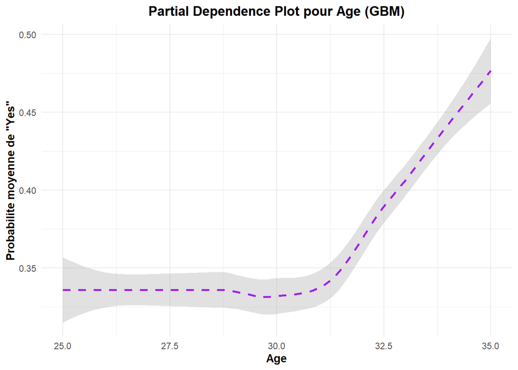

```r
print(plot2)
```

**AnnualIncome :**

**Age :**

- La probabilité de souscription est minimale autour de **30 ans**, puis **augmente progressivement** après cet âge.
- **Interprétation** : les clients plus âgés (au-delà de 32 ans) semblent accorder plus d’intérêt à l’assurance voyage, peut-être par prudence ou habitudes d’achat différentes.

Pour ce qui des interactions, le modèle de Gradient Boosting (GBM) est particulièrement performant pour modéliser des effets non linéaires ainsi que des interactions complexes entre variables. Ces interactions ne sont pas spécifiées explicitement, mais elles émergent naturellement à travers la construction séquentielle d’arbres.

# 4 **Comparaison des modeles**

```r
set.seed(123)

# Renommer proprement les colonnes si nécessaire
colnames(base) <- make.names(colnames(base), unique = TRUE)
names(base)[names(base) == "Employment.Type"] <- "Employment_Type"

# Séparation en train/test
in_training <- createDataPartition(y = base$TravelInsurance, p = 0.8, list = FALSE)
training_set <- base[in_training, ]
testing_set  <- base[-in_training, ]

# Encodage binaire
training_set$TravelInsurance <- factor(training_set$TravelInsurance, levels = c("No", "Yes"))
testing_set$TravelInsurance  <- factor(testing_set$TravelInsurance, levels = c("No", "Yes"))

# ================================================================
# 1. ARBRE ÉLAGUÉ OPTIMAL
# ================================================================

best_cp <- cv_model$bestTune$cp
cv_accuracy_tree <- max(cv_model$results$Accuracy, na.rm = TRUE)
```

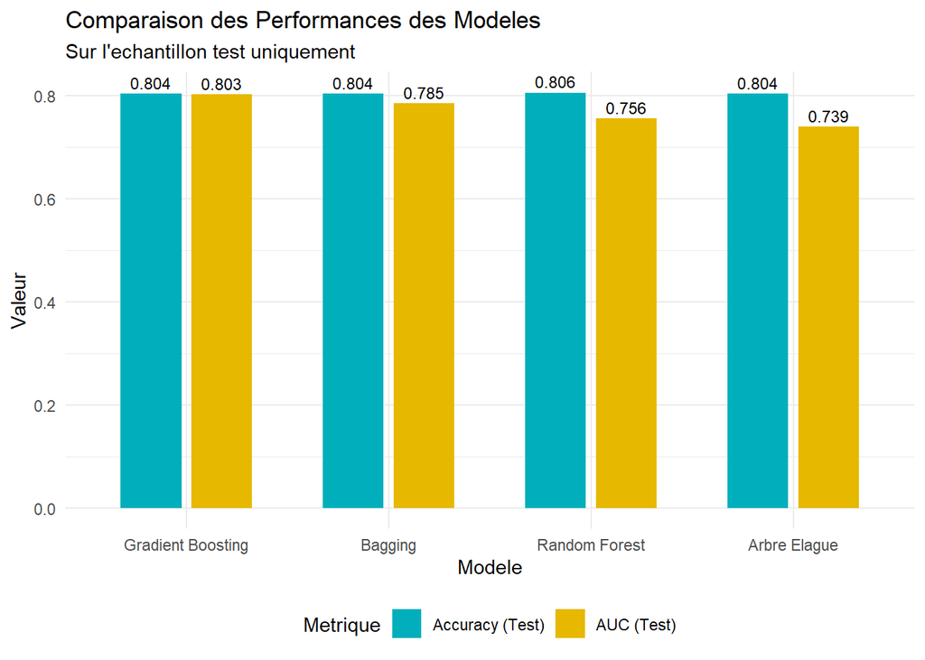

```r
cv_error_tree <- 1 - cv_accuracy_tree

pred_tree_test <- predict(arbre_optimal, testing_set, type = "class")
pred_tree_prob <- predict(arbre_optimal, testing_set, type = "prob")[, "Yes"]

accuracy_tree <- mean(pred_tree_test == testing_set$TravelInsurance)
roc_tree <- pROC::roc(testing_set$TravelInsurance, pred_tree_prob, quiet = TRUE)
auc_tree <- pROC::auc(roc_tree)

# ================================================================
# 2. MODÈLE BAGGING
# ================================================================

# Fonction de prédiction bagging
predict_bagging <- function(models, newdata) {
  probs <- sapply(models, function(model) {
    predict(model, newdata, type = "prob")[, "Yes"]
  })
  avg_prob <- rowMeans(probs, na.rm = TRUE)
  pred_class <- factor(ifelse(avg_prob > 0.5, "Yes", "No"), levels = c("No", "Yes"))
  list(class = pred_class, prob = avg_prob)
}

# Erreur OOB
oob_errors <- sapply(bagg_cart, function(model) {
  pred_train <- predict(model, training_set, type = "class")
  mean(pred_train != training_set$TravelInsurance)
})
cv_error_bagging <- mean(oob_errors)
cv_accuracy_bagging <- 1 - cv_error_bagging

# Prédictions
pred_bagging <- predict_bagging(bagg_cart, testing_set)
accuracy_bagging <- mean(pred_bagging$class == testing_set$TravelInsurance)
roc_bagging <- roc(testing_set$TravelInsurance, pred_bagging$prob, quiet = TRUE)
auc_bagging <- auc(roc_bagging)


# ================================================================
# 3. RANDOM FOREST
# ================================================================

cv_error_rf <- tail(final_rf$err.rate[, "OOB"], 1)
cv_accuracy_rf <- 1 - cv_error_rf

pred_rf_test <- predict(final_rf, testing_set, type = "class")
pred_rf_prob <- predict(final_rf, testing_set, type = "prob")[, "Yes"]

accuracy_rf <- mean(pred_rf_test == testing_set$TravelInsurance)
roc_rf <- roc(testing_set$TravelInsurance, pred_rf_prob, quiet = TRUE)
auc_rf <- auc(roc_rf)

# ================================================================
# 4. GRADIENT BOOSTING
# ================================================================

# Préparer les données
training_set$TravelInsurance_num <- ifelse(training_set$TravelInsurance == "Yes", 1, 0)
testing_set$TravelInsurance_num  <- ifelse(testing_set$TravelInsurance == "Yes", 1, 0)

# Facteurs pour gbm
cat_vars <- c("Employment_Type", "GraduateOrNot", "ChronicDiseases", "FrequentFlyer", "EverTravelledAbroad")
training_set[cat_vars] <- lapply(training_set[cat_vars], factor)
testing_set[cat_vars]  <- lapply(testing_set[cat_vars], factor)

cv_error_gbm <- final_model$cv.error[best_iter_final]
cv_accuracy_gbm <- 1 - cv_error_gbm

pred_gbm_prob <- predict(final_model, testing_set, n.trees = best_iter_final, type = "response")
pred_gbm_test <- factor(ifelse(pred_gbm_prob > 0.5, "Yes", "No"), levels = c("No", "Yes"))

accuracy_gbm <- mean(pred_gbm_test == testing_set$TravelInsurance)
roc_gbm <- roc(testing_set$TravelInsurance, pred_gbm_prob, quiet = TRUE)
auc_gbm <- auc(roc_gbm)


# ================================================================
# TABLEAU COMPARATIF FINAL
# ================================================================

# === Tableau de performance : uniquement AUC et Test Accuracy ===

performance_comparative <- data.frame(
  Modele = c("Arbre Elague", "Bagging", "Random Forest", "Gradient Boosting"),
  Test_Accuracy = c(accuracy_tree, accuracy_bagging, accuracy_rf, accuracy_gbm),
  Test_AUC = c(auc_tree, auc_bagging, auc_rf, auc_gbm)
)

# === Réorganisation pour affichage dans ggplot ===

perf_melted <- melt(performance_comparative,
                    id.vars = "Modele",
                    variable.name = "Metrique",
                    value.name = "Valeur")

perf_melted$Metrique <- factor(perf_melted$Metrique,
                               levels = c("Test_Accuracy", "Test_AUC"),
                               labels = c("Accuracy (Test)", "AUC (Test)"))

# === Graphique combiné Accuracy & AUC ===

ggplot(perf_melted, aes(x = reorder(Modele, -Valeur), y = Valeur, fill = Metrique)) +
  geom_bar(stat = "identity", position = position_dodge(width = 0.7), width = 0.6) +
  geom_text(aes(label = round(Valeur, 3)), position = position_dodge(0.7),
            vjust = -0.4, size = 3.2) +
  labs(title = "Comparaison des Performances des Modeles",
       subtitle = "Sur l'echantillon test uniquement",
       x = "Modele", y = "Valeur") +
  scale_fill_manual(values = c("Accuracy (Test)" = "#00AFBB", "AUC (Test)" = "#E7B800")) +
  theme_minimal() +
  theme(legend.position = "bottom",
        strip.text = element_text(face = "bold"))
```

**Comparaison des performances et choix du meilleur modèle**

Afin d’identifier le modèle le plus performant pour prédire la souscription à une assurance voyage, nous avons comparé quatre approches supervisées : **Gradient Boosting**, **Bagging**, **Random Forest** et **Arbre élagué**. Les performances ont été évaluées sur l’échantillon test selon deux métriques complémentaires :

- **Accuracy (précision globale)**
- **AUC (Area Under the ROC Curve)**, qui mesure la capacité de classement du modèle.

**Analyse comparative**

## 4.2 **Implications actuarielles**

Du point de vue actuariel, ces résultats suggèrent que :

1. **Le profil socio-économique** (revenu) est le facteur déterminant dans la décision de souscription, permettant une **segmentation claire de la clientèle**.
2. **L’expérience de voyage** constitue un indicateur comportemental pertinent pour affiner le ciblage marketing.
3. La **simplicité de l’arbre de décision** (basé principalement sur le revenu) offre un outil de communication efficace avec les équipes commerciales et marketing.

## 4.3 **Perspectives d’amélioration**

Plusieurs axes d’amélioration pourraient être explorés :

- **Enrichissement des données** : intégration de variables comportementales supplémentaires (historique d’achat, données de navigation web, saisonnalité des voyages).
- **Techniques avancées** : test de méthodes plus récentes (XGBoost, LightGBM, réseaux de neurones).
- **Optimisation métier** : calibrage des seuils de décision en fonction des objectifs business (optimisation du profit vs volume, coût d’acquisition client).

## 4.4 **Conclusion**

Ce travail illustre l’efficacité des méthodes d’ensemble en actuariat et fournit une base solide pour le développement d’outils d’aide à la décision en assurance voyage. La convergence des résultats entre les différents modèles concernant l’importance du revenu annuel renforce la robustesse des conclusions et offre une direction claire pour les stratégies de ciblage commercial.